# Machine Learning Project: Potability

Quentin Le Boulch and Nico Palermo

2024-05-18

## Introduction

This project aims to analyze water potability using various machine learning techniques applied to a specific dataset. We set up several models to evaluate the prediction capacity of each method and compare their performances. We’ll see several supervised classification techniques by training set model, tree, random forrest logit model and tree nnet models

## Library

We installed several library to perform our different test and models

## 1. Dataset

We download the dataset from Kaggle: https://www.kaggle.com/datasets/nayanack/water-probability/data

The data provides information about whether the water is potable or not, based on various water characteristics variables.

There is 9 explicative variables and the 10th variable is whether the is potable or not:

pH: pH of the water (measured in pH units).

Hardness: Hardness of the water (measured in mg/L).

Solids: Total dissolved solids in the water (measured in ppm).

Chloramines: Amount of chloramines in the water (measured in ppm).

Sulfate: Amount of sulfate in the water (measured in mg/L).

Conductivity: Conductivity of the water (measured in μS/cm).

Organic_carbon: Amount of organic carbon in the water (measured in ppm).

Trihalomethanes: Amount of trihalomethanes in the water (measured in μg/L).

Turbidity: Turbidity of the water (measured in NTU).

Potability: Potability of the water (1 indicates potable, 0 indicates non-potable).

Summary Statistics:

The dataset contains 3276 entries. The columns “pH”, “Sulfate”, and “Trihalomethanes” have missing values. The data types of the columns are float64 for features and int64 for the target variable (Potability).

```r
setwd("C:/Users/quent/OneDrive - Université Côte d'Azur/Documents/MasterEE/s2/Big Data")



ptbl<- read.csv("water_potability.csv")

str(ptbl)
```

```
## 'data.frame':    3276 obs. of  10 variables:
##  $ ph             : num  NA 3.72 8.1 8.32 9.09 ...
##  $ Hardness       : num  205 129 224 214 181 ...
##  $ Solids         : num  20791 18630 19910 22018 17979 ...
##  $ Chloramines    : num  7.3 6.64 9.28 8.06 6.55 ...
##  $ Sulfate        : num  369 NA NA 357 310 ...
##  $ Conductivity   : num  564 593 419 363 398 ...
##  $ Organic_carbon : num  10.4 15.2 16.9 18.4 11.6 ...
##  $ Trihalomethanes: num  87 56.3 66.4 100.3 32 ...
##  $ Turbidity      : num  2.96 4.5 3.06 4.63 4.08 ...
##  $ Potability     : int  0 0 0 0 0 0 0 0 0 0 ...
```

```r
head(ptbl)
```

```
##         ph Hardness   Solids Chloramines  Sulfate Conductivity Organic_carbon
## 1       NA 204.8905 20791.32    7.300212 368.5164     564.3087      10.379783
## 2 3.716080 129.4229 18630.06    6.635246       NA     592.8854      15.180013
## 3 8.099124 224.2363 19909.54    9.275884       NA     418.6062      16.868637
## 4 8.316766 214.3734 22018.42    8.059332 356.8861     363.2665      18.436524
## 5 9.092223 181.1015 17978.99    6.546600 310.1357     398.4108      11.558279
## 6 5.584087 188.3133 28748.69    7.544869 326.6784     280.4679       8.399735
##   Trihalomethanes Turbidity Potability
## 1        86.99097  2.963135          0
## 2        56.32908  4.500656          0
## 3        66.42009  3.055934          0
## 4       100.34167  4.628771          0
## 5        31.99799  4.075075          0
## 6        54.91786  2.559708          0
```

```r
summary(ptbl)
```

```
##        ph            Hardness          Solids         Chloramines
##  Min.   : 0.000   Min.   : 47.43   Min.   :  320.9   Min.   : 0.352
##  1st Qu.: 6.093   1st Qu.:176.85   1st Qu.:15666.7   1st Qu.: 6.127
##  Median : 7.037   Median :196.97   Median :20927.8   Median : 7.130
##  Mean   : 7.081   Mean   :196.37   Mean   :22014.1   Mean   : 7.122
##  3rd Qu.: 8.062   3rd Qu.:216.67   3rd Qu.:27332.8   3rd Qu.: 8.115
##  Max.   :14.000   Max.   :323.12   Max.   :61227.2   Max.   :13.127
##  NA's   :491
##     Sulfate       Conductivity   Organic_carbon  Trihalomethanes
##  Min.   :129.0   Min.   :181.5   Min.   : 2.20   Min.   :  0.738
##  1st Qu.:307.7   1st Qu.:365.7   1st Qu.:12.07   1st Qu.: 55.845
##  Median :333.1   Median :421.9   Median :14.22   Median : 66.622
##  Mean   :333.8   Mean   :426.2   Mean   :14.28   Mean   : 66.396
##  3rd Qu.:360.0   3rd Qu.:481.8   3rd Qu.:16.56   3rd Qu.: 77.337
##  Max.   :481.0   Max.   :753.3   Max.   :28.30   Max.   :124.000
##  NA's   :781                                     NA's   :162
##    Turbidity       Potability
##  Min.   :1.450   Min.   :0.0000
##  1st Qu.:3.440   1st Qu.:0.0000
##  Median :3.955   Median :0.0000
##  Mean   :3.967   Mean   :0.3901
##  3rd Qu.:4.500   3rd Qu.:1.0000
##  Max.   :6.739   Max.   :1.0000
##
```

## 2 Training Model

We create the training model with 3/4 of our data We create the test set to test our model. The test set is composed by the individual who aren’t in the training set so 25%

There are 2457 on the train and 819 in testing

```r
ptbl_train <- createDataPartition(y=ptbl$Potability, p=0.75, times=1, list=FALSE)
training <- ptbl[ptbl_train,]
dim(training)
```

```
## [1] 2457   10
```

```r
testing <- ptbl[-ptbl_train,]
dim(testing)
```

```
## [1] 819  10
```

We stacked the data and created the plots relating all the variables we have

```r
summary(training)
```

```
##        ph            Hardness          Solids         Chloramines
##  Min.   : 0.000   Min.   : 47.43   Min.   :  320.9   Min.   : 0.352
##  1st Qu.: 6.126   1st Qu.:177.35   1st Qu.:15570.1   1st Qu.: 6.132
##  Median : 7.038   Median :197.29   Median :20988.1   Median : 7.117
##  Mean   : 7.098   Mean   :196.61   Mean   :22044.5   Mean   : 7.105
##  3rd Qu.: 8.111   3rd Qu.:217.27   3rd Qu.:27420.2   3rd Qu.: 8.092
##  Max.   :14.000   Max.   :323.12   Max.   :56867.9   Max.   :12.912
##  NA's   :367
##     Sulfate       Conductivity   Organic_carbon   Trihalomethanes
##  Min.   :129.0   Min.   :181.5   Min.   : 4.467   Min.   :  8.176
##  1st Qu.:307.7   1st Qu.:365.1   1st Qu.:12.068   1st Qu.: 55.836
##  Median :332.8   Median :420.8   Median :14.184   Median : 66.553
##  Mean   :333.4   Mean   :425.7   Mean   :14.280   Mean   : 66.419
##  3rd Qu.:359.2   3rd Qu.:481.2   3rd Qu.:16.520   3rd Qu.: 77.315
##  Max.   :476.5   Max.   :753.3   Max.   :28.300   Max.   :120.030
##  NA's   :575                                      NA's   :124
##    Turbidity       Potability
##  Min.   :1.450   Min.   :0.0000
##  1st Qu.:3.441   1st Qu.:0.0000
##  Median :3.964   Median :0.0000
##  Mean   :3.971   Mean   :0.3911
##  3rd Qu.:4.494   3rd Qu.:1.0000
##  Max.   :6.495   Max.   :1.0000
##
```

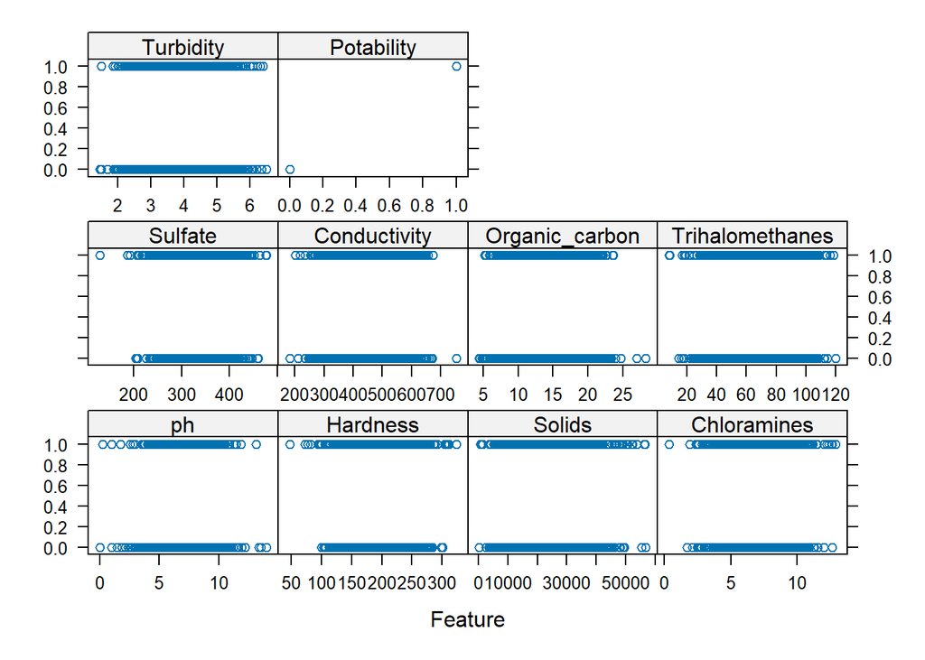

```r
featurePlot(x=training, y = training$Potability,)
```

## 3 Tree

The use of a decision tree in our project serves to better understand the data, identifying important variables

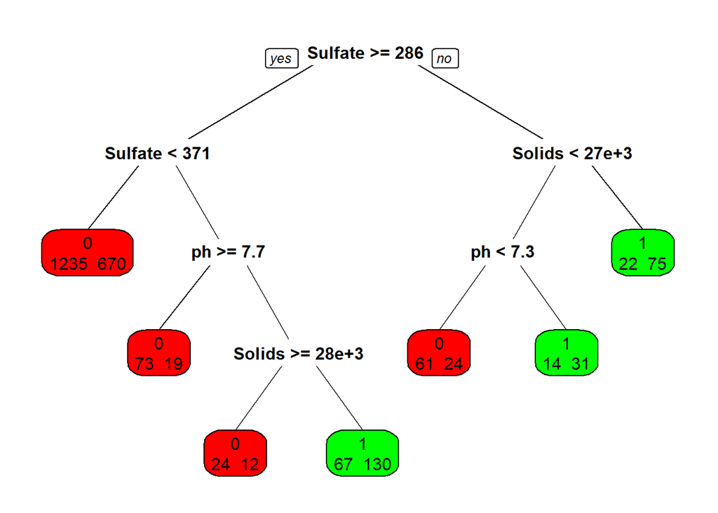

```r
tree <- rpart(Potability~.,data=training, method = "class")
prp(tree,extra=1,faclen=5, box.col=c("red","green")[tree$frame$yval])
```

To verify this supposition we check forvariables importance on the tree

```r
tree$variable.importance
```

```
##             ph        Sulfate         Solids       Hardness    Chloramines
##     33.9962284     30.0305544     20.8333734      2.3924873      1.3865123
## Organic_carbon      Turbidity   Conductivity
##      1.3524949      0.8673015      0.7020188
```

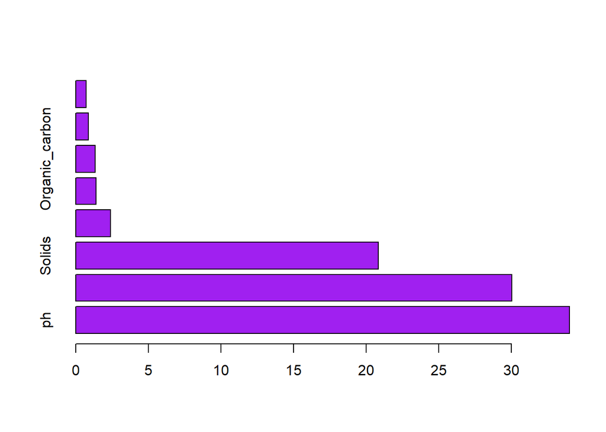

```r
barplot(tree$variable.importance, horiz = TRUE, col = "purple")
```

This graph is the comparison between the variable ph and Sulfate because they are the most impactful variable to determine if the water is potable or not

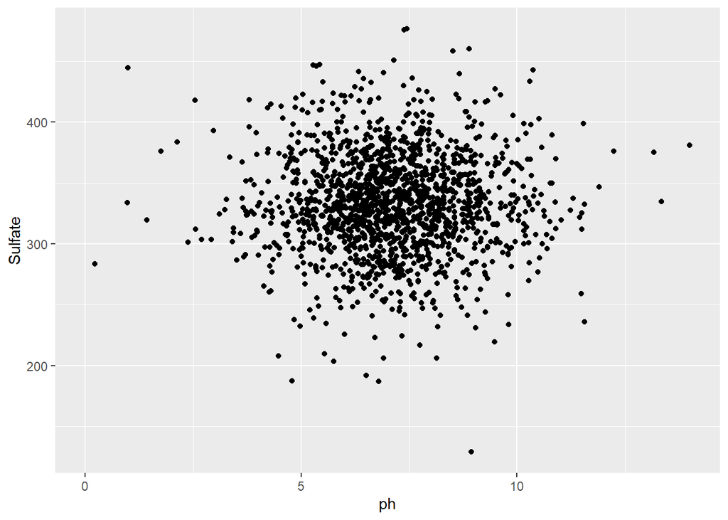

```r
qplot(ph, Sulfate, data=training)
```

Next, we test correlation between the 2 variables

```r
cor.test(ptbl$ph,ptbl$Sulfate)
```

```
##
##  Pearson's product-moment correlation
##
## data:  ptbl$ph and ptbl$Sulfate
## t = 0.83709, df = 2114, p-value = 0.4026
## alternative hypothesis: true correlation is not equal to 0
## 95 percent confidence interval:
##  -0.02442818  0.06076829
## sample estimates:
##       cor
## 0.0182031
```

The results show that the correlation is not significant (p-value is large 0.4026).

We compute the prediction with our data test and after that we’re able to compute the confusion matrix. Confusion matrix allow to asses the precision and accuracy of our supervised classification.

```r
tree_prediction <- predict(tree, testing, type="class")
confusionMatrix(as.factor(testing$Potability),tree_prediction)
```

```
## Confusion Matrix and Statistics
##
##           Reference
## Prediction   0   1
##          0 461  41
##          1 260  57
##
##                Accuracy : 0.6325
##                  95% CI : (0.5984, 0.6656)
##     No Information Rate : 0.8803
##     P-Value [Acc > NIR] : 1
##
##                   Kappa : 0.1125
##
##  Mcnemar's Test P-Value : <2e-16
##
##             Sensitivity : 0.6394
##             Specificity : 0.5816
##          Pos Pred Value : 0.9183
##          Neg Pred Value : 0.1798
##              Prevalence : 0.8803
##          Detection Rate : 0.5629
##    Detection Prevalence : 0.6129
##       Balanced Accuracy : 0.6105
##
##        'Positive' Class : 0
##
```

## 4 Random Forest

The random forest algorithm creates multiple decision trees using different subsets of the data and averages their predictions to improve accuracy and prevent overfitting. It highlights the most important variables contributing to the model’s predictions by assessing their impact across all trees.

For this method, we train it on training, then we predict thanks to this training on testing and we compare.

```r
training_complete <- na.omit(training)
randomf1 <- randomForest(as.factor(training_complete$Potability) ~ ., data = training_complete)
randomf1_pred <- predict(randomf1, testing, type="response")

importance(randomf1)
```

```
##                 MeanDecreaseGini
## ph                     104.09332
## Hardness                85.68413
## Solids                  79.89749
## Chloramines             81.77579
## Sulfate                107.33295
## Conductivity            69.30076
## Organic_carbon          68.37028
## Trihalomethanes         69.67224
## Turbidity               65.19686
```

A higher value means that the feature contributes more to reducing uncertainty about class labels, and is therefore more important. So this give usthe importance of each variable in the creation of the tree Sulfate and PH have the mean decrease Gini higher so there are the most importante variables.

```r
confusionMatrix(as.factor(testing$Potability),randomf1_pred)
```

```
## Confusion Matrix and Statistics
##
##           Reference
## Prediction   0   1
##          0 244  49
##          1 120  77
##
##                Accuracy : 0.6551
##                  95% CI : (0.6112, 0.6972)
##     No Information Rate : 0.7429
##     P-Value [Acc > NIR] : 1
##
##                   Kappa : 0.2377
##
##  Mcnemar's Test P-Value : 7.26e-08
##
##             Sensitivity : 0.6703
##             Specificity : 0.6111
##          Pos Pred Value : 0.8328
##          Neg Pred Value : 0.3909
##              Prevalence : 0.7429
##          Detection Rate : 0.4980
##    Detection Prevalence : 0.5980
##       Balanced Accuracy : 0.6407
##
##        'Positive' Class : 0
##
```

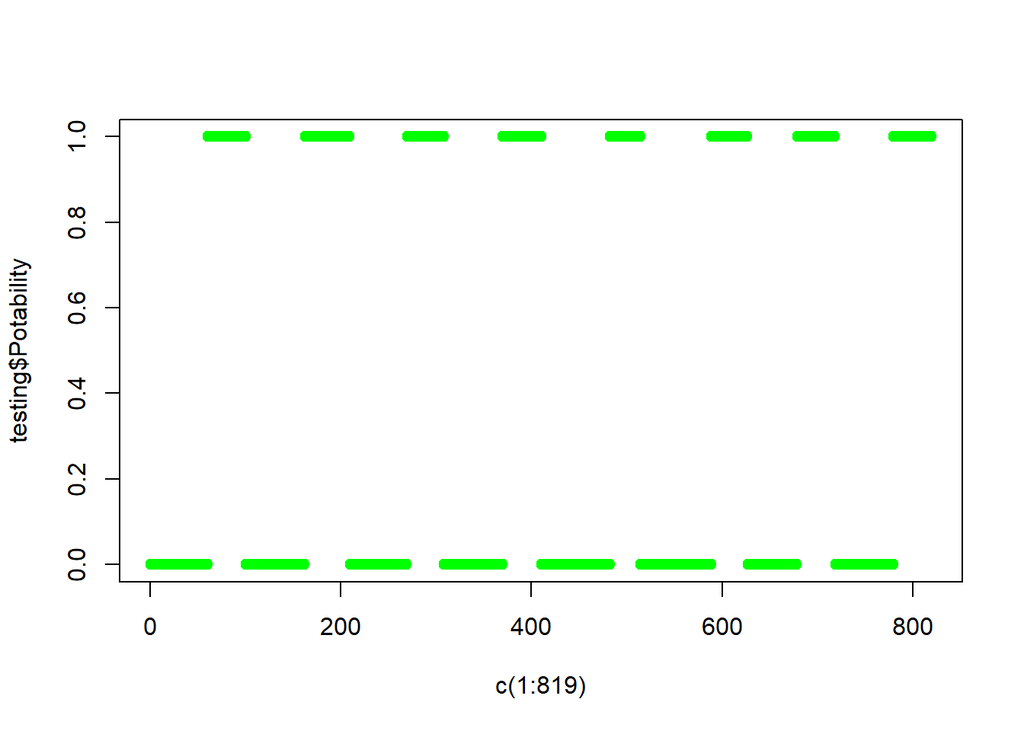

```r
plot(c(1:819), testing$Potability, col ="green")
```

## 5. Logit Model

We did another model, the logit one. The logit model, is a supervised machine learning algorithm used for binary classification tasks. It estimates the probability that a given input belongs to a certain class by applying the logistic function to a linear combination of the input features.

```r
datapr = as.numeric(predictions>0.75)
reference = testing$Potability
confusionMatrix(as.factor(datapr), as.factor(reference))
```

```
## Confusion Matrix and Statistics
##
##           Reference
## Prediction   0   1
##          0 293 197
##          1   0   0
##
##                Accuracy : 0.598
##                  95% CI : (0.553, 0.6417)
##     No Information Rate : 0.598
##     P-Value [Acc > NIR] : 0.5196
##
##                   Kappa : 0
##
##  Mcnemar's Test P-Value : <2e-16
##
##             Sensitivity : 1.000
##             Specificity : 0.000
##          Pos Pred Value : 0.598
##          Neg Pred Value :   NaN
##              Prevalence : 0.598
##          Detection Rate : 0.598
##    Detection Prevalence : 1.000
##       Balanced Accuracy : 0.500
##
##        'Positive' Class : 0
##
```

The model predict 0 for each result so all the water to be . This model is not good because we predict for all individuals 0. We can see the accuracy is very low 59% Maybe something is wrong ? We dont take this model as a reference to explain our study.

## 6. Tree Nnet

The TreeNet model combines decision trees and neural networks to leverage the strengths of both techniques. It uses decision trees to handle non-linear relationships and interactions, while neural networks refine these predictions for improved accuracy in classification tasks.

```r
data = as.numeric(nn_prob>0.5)
reference = testing$Potability
confusionMatrix(as.factor(data), as.factor(reference))
```

```
## Confusion Matrix and Statistics
##
##           Reference
## Prediction   0   1
##          0 293 197
##          1   0   0
##
##                Accuracy : 0.598
##                  95% CI : (0.553, 0.6417)
##     No Information Rate : 0.598
##     P-Value [Acc > NIR] : 0.5196
##
##                   Kappa : 0
##
##  Mcnemar's Test P-Value : <2e-16
##
##             Sensitivity : 1.000
##             Specificity : 0.000
##          Pos Pred Value : 0.598
##          Neg Pred Value :   NaN
##              Prevalence : 0.598
##          Detection Rate : 0.598
##    Detection Prevalence : 1.000
##       Balanced Accuracy : 0.500
##
##        'Positive' Class : 0
##
```

##7 A new to asses mising values

For now we’re testing a model with droping all observations where there is missing values. Indeed, our approach involve dropping observations with missing values, have reduced the dataset’s overall size and affected model performance. More sophisticated imputation techniques could yield better results

```r
training2 <- na.omit(training)
testing2 <- na.omit(testing)
```

We did it again a tree and a confusion matrix…

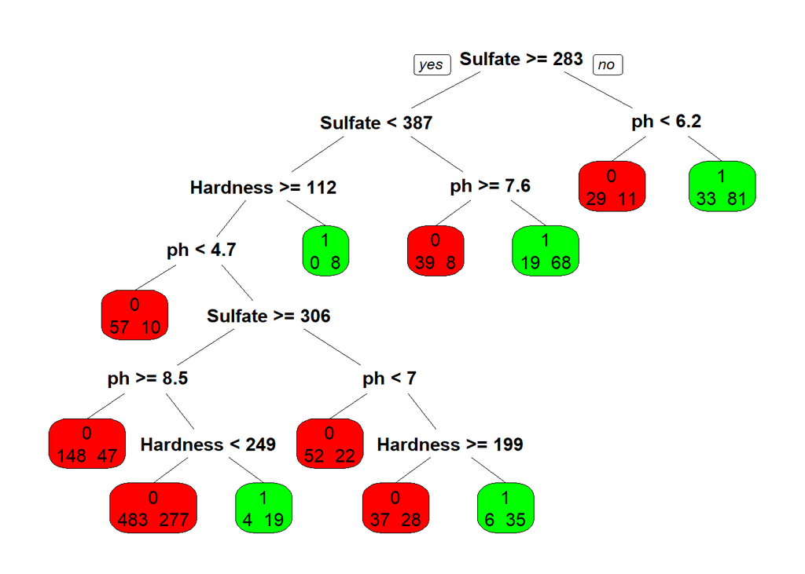

```r
tree <- rpart(Potability~.,data=training2, method = "class")
prp(tree,extra=1,faclen=5, box.col=c("red","green")[tree$frame$yval])
```

```r
tree_prediction2 <- predict(tree, testing, type="class")
confusionMatrix(as.factor(testing$Potability),tree_prediction2)
```

```
## Confusion Matrix and Statistics
##
##           Reference
## Prediction   0   1
##          0 448  54
##          1 251  66
##
##                Accuracy : 0.6276
##                  95% CI : (0.5935, 0.6608)
##     No Information Rate : 0.8535
##     P-Value [Acc > NIR] : 1
##
##                   Kappa : 0.1136
##
##  Mcnemar's Test P-Value : <2e-16
##
##             Sensitivity : 0.6409
##             Specificity : 0.5500
##          Pos Pred Value : 0.8924
##          Neg Pred Value : 0.2082
##              Prevalence : 0.8535
##          Detection Rate : 0.5470
##    Detection Prevalence : 0.6129
##       Balanced Accuracy : 0.5955
##
##        'Positive' Class : 0
##
```

This model gave us a bit lower accuracy than first one.

## 8. Conclusion and limits

In summary, our study aimed to predict water potability using various machine learning models. We explored decision trees, random forests, logistic regression, and TreeNet models, identifying sulfate and pH as significant predictors.

Some models, like logistic regression and TreeNet, showed poor performance, indicating potential issues with model choice or parameter settings. Further tuning and optimization are required. The study did not explore advanced feature machine learning techniques that could potentially improve the models predictive power. The dataset’s size and the presence of missing or noisy data may have impacted the accuracy and generalizability of our models. Also, our study did not explicitly address the presence of outliers in the dataset. Outliers can skew the results and affect the accuracy of the models, potentially leading to biased predictions. Detecting and appropriately handling outliers could improve the robustness and reliability of our models.